# act_report

## Report: act_report

Monique van den Berg

Using the tidy master dataset consisting of the WeRateDogs tweet archive, tweepy gather data and image predictions insights and a visualization were produced by answering the following questions.

#### Question(s) for Analysis:

- What is the most popular dog name?
- Which dog stage was mentioned the most?
- Which tweet has the highest favorite count?
- Which tweet has the lowest favorite count?
- Which tweet has the highest retweet count?
- Which tweet has the lowest retweet count?
- Which tweet has the highest rating?
- Which tweet has the lowest rating?
- Which predicted dog breed is the most popular?

#### Insights:

1. Lucy is the most popular dog name and was mentioned in 10 tweets.
2. Pupper was mentioned 223 times and is the most mentioned dog stage.
3. Tweet with tweet id: 822872901745569793 and text: "Here's a super supportive puppo participating in the Toronto #WomensMarch today. 13/10 https://t.co/nTz3FtorBc" is the tweet with the highest favorite count of 132810.
4. Tweet with tweet id: 666102155909144576 and text: "Oh my. Here you are seeing an Adobe Setter giving birth to twins!!! The world is an amazing place. 11/10 https://t.co/11LvqN4WLq" is the tweet with the lowest favorite count of 81.
5. Tweet with tweet id: 744234799360020481 and text: "Here's a doggo realizing you can stand in a pool. 13/10 enlightened af (vid by Tina Conrad) https://t.co/7wE9LTEXC4" is the tweet that has been retweeted the most number of times 79515.
6. Tweet with tweet id: 666102155909144576 and text: "Oh my. Here you are seeing an Adobe Setter giving birth to twins!!! The world is an amazing place. 11/10 https://t.co/11LvqN4WLq" is the tweet that has been retweeted the least number of times, only 16.
7. The tweet with the lowest favorite count and lowest retweet count is the same tweet with tweet id: 666102155909144576.
8. Tweet with tweet id: 749981277374128128 and text: "This is Atticus. He's quite simply America af. 1776/10 https://t.co/GRXwMxLBkh" is the tweet with the highest rating of 1776/10.
9. Tweet with tweet id: 835152434251116546 and text: "When you're so blinded by your systematic plagiarism that you forget what day it is. 0/10 https://t.co/YbEJPkg4Ag" is the tweet with the lowest rating of 0/10.

#### Visualization

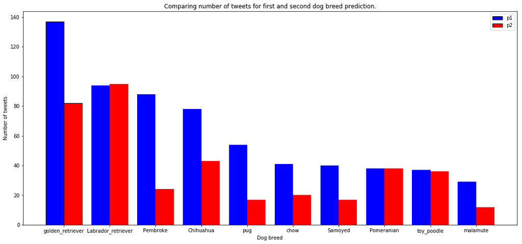

From the above chart we see that golden retriever is the predicted most popular dog breed.